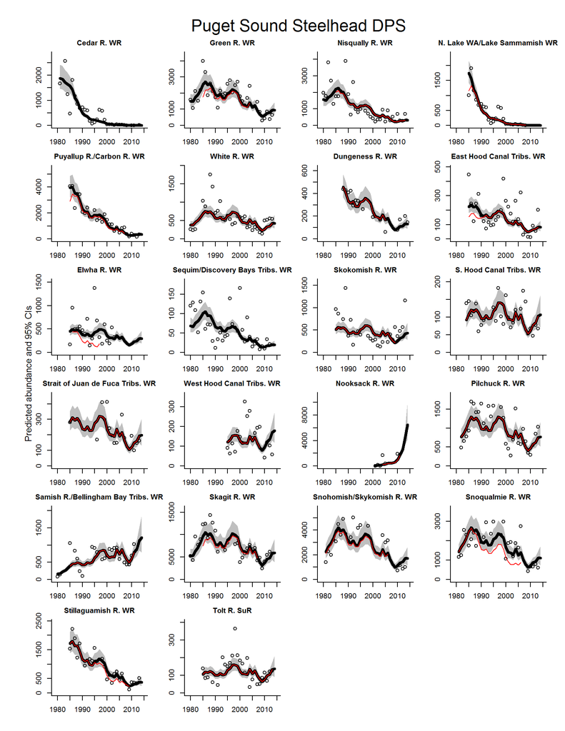

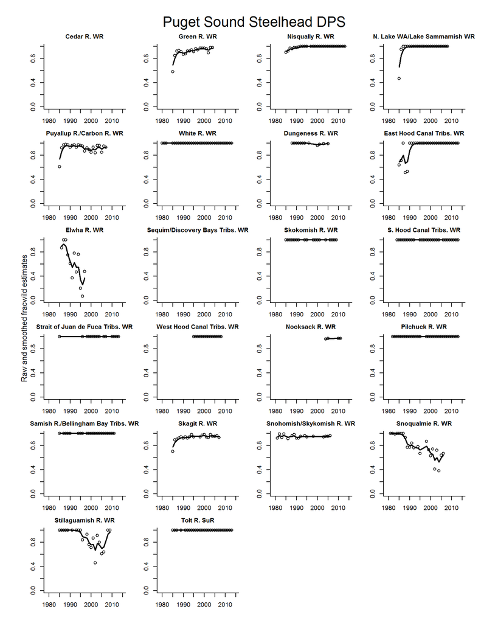

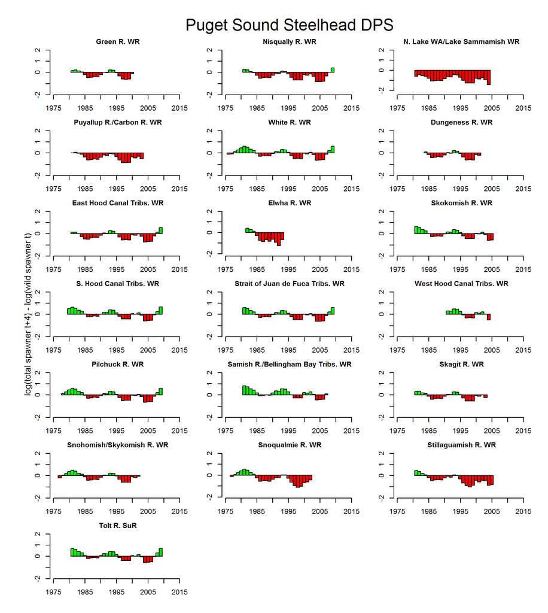

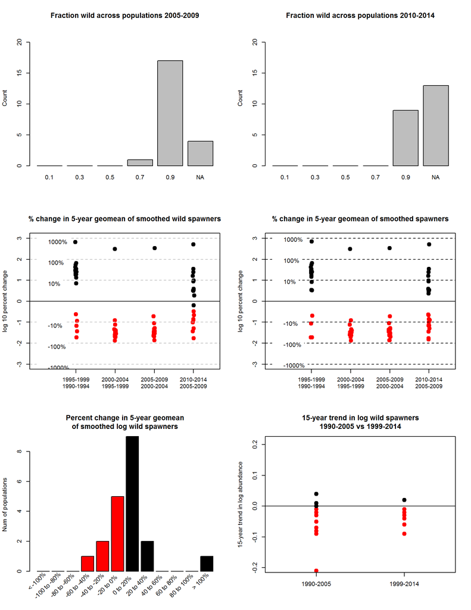

5-year geometric mean of smoothed wild spawner estimate (smoothed total spawners times smoothed fracwild). In parentheses, the 5-year geometric mean of smoothed total spawners (black thick line in graphs) is shown. A row with only values in parentheses indicates that no fraction wild estimates were available for that population. Geometric mean was computed as the product of counts raised to the power 1/5. Percent change between the most recent two 5-year periods is shown on the far right.

Population

MPG

1990-1994

1995-1999

2000-2004

2005-2009

2010-2014

% Change

Cedar R. WR

Central & South PS

(-67)

Green R. WR

Central & South PS

1648 (1815)

1978 (2082)

1269 (1327)

843 (868)

782 (806)

-7 (-7)

Nisqually R. WR

Central & South PS

1210 (1219)

1159 (1159)

624 (624)

354 (354)

283 (283)

-20 (-20)

N. Lake WA/Lake Sammamish WR

Central & South PS

359 (359)

169 (169)

44 (44)

12 (12)

5 (5)

-58 (-58)

Puyallup R./Carbon R. WR

Central & South PS

1883 (1977)

1606 (1752)

786 (869)

410 (444)

298 (321)

-27 (-28)

White R. WR

Central & South PS

559 (559)

687 (687)

475 (475)

342 (342)

353 (353)

3 (3)

Dungeness R. WR

Hood Canal & SJF

309 (309)

331 (335)

199 (203)

127 (128)

114 (115)

-10 (-10)

East Hood Canal Tribs. WR

Hood Canal & SJF

152 (158)

181 (181)

116 (116)

76 (76)

70 (70)

-8 (-8)

Elwha R. WR

Hood Canal & SJF

214 (370)

156 (464)

120 (325)

87 (237)

90 (245)

3 (3)

Sequim/Discovery Bays Tribs. WR

Hood Canal & SJF

(-14)

Skokomish R. WR

Hood Canal & SJF

435 (435)

562 (562)

410 (410)

317 (317)

348 (348)

10 (10)

S. Hood Canal Tribs. WR

Hood Canal & SJF

97 (97)

131 (131)

99 (99)

78 (78)

85 (85)

9 (9)

Strait of Juan de Fuca Tribs. WR

Hood Canal & SJF

236 (236)

300 (300)

212 (212)

156 (156)

162 (162)

4 (4)

West Hood Canal Tribs. WR

Hood Canal & SJF

93 (93)

143 (143)

124 (124)

110 (110)

137 (137)

25 (25)

Nooksack R. WR

Northern Cascades

3 (3)

23 (24)

94 (98)

413 (426)

2537 (2616)

514 (514)

Pilchuck R. WR

Northern Cascades

970 (970)

1207 (1207)

838 (838)

609 (609)

628 (628)

3 (3)

Samish R./Bellingham Bay Tribs. WR

Northern Cascades

464 (464)

763 (763)

700 (700)

663 (663)

894 (894)

35 (35)

Skagit R. WR

Northern Cascades

7240 (7717)

9073 (9530)

6316 (6614)

4508 (4773)

4592 (4884)

2 (2)

Snohomish/Skykomish R. WR

Northern Cascades

2765 (2933)

3266 (3447)

2134 (2254)

1451 (1519)

1385 (1449)

-5 (-5)

Snoqualmie R. WR

Northern Cascades

1467 (1877)

1663 (2214)

872 (1453)

617 (983)

598 (940)

-3 (-4)

Stillaguamish R. WR

Northern Cascades

1065 (1072)

974 (1109)

477 (641)

316 (386)

318 (330)

1 (-15)

Tolt R. SuR

Northern Cascades

104 (104)

147 (147)

115 (115)

93 (93)

108 (108)

16 (16)

5-year geometric mean of raw wild spawner counts. This is the raw total spawner count times the fraction wild estimate, if available. In parentheses, 5-year geometric mean of raw total spawner counts is shown. A value only in parentheses means that a total spawner count was available but no or only one estimate of wild spawners available. The geometric mean was computed as the product of counts raised to the power 1 over the number of counts available (2 to 5). A minimum of 2 values were used to compute the geometric mean. Percent change between the most recent two 5-year periods is shown on the far right.

Population

MPG

1990-1994

1995-1999

2000-2004

2005-2009

2010-2014

% Change

Cedar R. WR

Central & South PS

(-67)

Green R. WR

Central & South PS

1566 (1730)

2379 (2505)

1618 (1693)

(-23)

Nisqually R. WR

Central & South PS

1201 (1208)

759 (759)

413 (413)

375 (375)

442 (442)

18 (18)

N. Lake WA/Lake Sammamish WR

Central & South PS

321 (321)

298 (298)

37 (37)

12 (12)

Puyallup R./Carbon R. WR

Central & South PS

1860 (1954)

1523 (1660)

907 (1000)

641 (476)

(-42)

White R. WR

Central & South PS

696 (696)

519 (519)

466 (466)

225 (225)

531 (531)

136 (136)

Dungeness R. WR

Hood Canal & SJF

356 (356)

182 (186)

East Hood Canal Tribs. WR

Hood Canal & SJF

110 (110)

176 (176)

202 (202)

62 (62)

60 (60)

-3 (-3)

Elwha R. WR

Hood Canal & SJF

206 (358)

127 (508)

Sequim/Discovery Bays Tribs. WR

Hood Canal & SJF

Skokomish R. WR

Hood Canal & SJF

503 (385)

359 (359)

259 (205)

351 (351)

S. Hood Canal Tribs. WR

Hood Canal & SJF

89 (89)

111 (111)

103 (103)

113 (113)

64 (64)

-43 (-43)

Strait of Juan de Fuca Tribs. WR

Hood Canal & SJF

275 (275)

212 (212)

244 (244)

147 (147)

-40 (-40)

West Hood Canal Tribs. WR

Hood Canal & SJF

97 (97)

210 (210)

174 (149)

(-50)

Nooksack R. WR

Northern Cascades

1779 (1834)

Pilchuck R. WR

Northern Cascades

1300 (1300)

1465 (1465)

604 (604)

597 (597)

614 (614)

3 (3)

Samish R./Bellingham Bay Tribs. WR

Northern Cascades

316 (316)

717 (717)

852 (852)

534 (534)

846 (846)

58 (58)

Skagit R. WR

Northern Cascades

7189 (7650)

7656 (8059)

5424 (5675)

5547 (4767)

Snohomish/Skykomish R. WR

Northern Cascades

3634 (3877)

4141 (4382)

2562 (2711)

2945 (3084)

(-70)

Snoqualmie R. WR

Northern Cascades

1832 (2328)

2060 (2739)

856 (1544)

1396 (1249)

(-46)

Stillaguamish R. WR

Northern Cascades

1078 (1078)

1024 (1166)

401 (550)

259 (327)

Tolt R. SuR

Northern Cascades

112 (112)

212 (212)

119 (119)

73 (73)

105 (105)

44 (44)

5-year mean of fraction wild (sum of all estimates divided by the number of estimates). Blanks mean no estimate available in that 5-year range.

| Population | 1990-1994 | 1995-1999 | 2000-2004 | 2005-2009 | 2010-2014 |
| --- | --- | --- | --- | --- | --- |
| Cedar R. WR |  |  |  |  |  |
| Green R. WR | 0.91 | 0.95 | 0.96 |  |  |
| Nisqually R. WR | 0.99 | 1.00 | 1.00 | 1.00 | 1.00 |
| N. Lake WA/Lake Sammamish WR | 1.00 | 1.00 | 1.00 | 1.00 |  |
| Puyallup R./Carbon R. WR | 0.95 | 0.92 | 0.91 | 0.91 |  |
| White R. WR | 1.00 | 1.00 | 1.00 | 1.00 | 1.00 |
| Dungeness R. WR | 1.00 | 1.00 | 0.98 | 0.99 |  |
| East Hood Canal Tribs. WR | 1.00 | 1.00 | 1.00 | 1.00 | 1.00 |
| Elwha R. WR | 0.60 | 0.25 |  |  |  |
| Sequim/Discovery Bays Tribs. WR |  |  |  |  |  |
| Skokomish R. WR | 1.00 | 1.00 | 1.00 | 1.00 |  |
| S. Hood Canal Tribs. WR | 1.00 | 1.00 | 1.00 | 1.00 | 1.00 |
| Strait of Juan de Fuca Tribs. WR |  | 1.00 | 1.00 | 1.00 | 1.00 |
| West Hood Canal Tribs. WR |  | 1.00 | 1.00 | 1.00 |  |
| Nooksack R. WR |  |  | 0.96 | 0.97 | 0.97 |
| Pilchuck R. WR | 1.00 | 1.00 | 1.00 | 1.00 | 1.00 |
| Samish R./Bellingham Bay Tribs. WR | 1.00 | 1.00 | 1.00 | 1.00 | 1.00 |
| Skagit R. WR | 0.94 | 0.95 | 0.96 | 0.95 |  |
| Snohomish/Skykomish R. WR | 0.94 | 0.95 | 0.94 | 0.96 |  |
| Snoqualmie R. WR | 0.79 | 0.76 | 0.58 | 0.66 |  |
| Stillaguamish R. WR | 1.00 | 0.88 | 0.75 | 0.81 |  |
| Tolt R. SuR | 1.00 | 1.00 | 1.00 | 1.00 | 1.00 |

15-year trends (slope) in log wild spawner abundance computed from a linear regression applied to the smoothed wild spawner log abundance estimate versus year. Only populations with at least 4 wild spawner estimates from 1980 to 2014 are shown and with at least 2 data points in the first 5 years and last 5 years of the 15-year period.

| Population | MPG | 1990-2005 | 1999-2014 |
| --- | --- | --- | --- |
| Green R. WR | Central & South PS | -0.03 (-0.05, -0.01) |  |
| Nisqually R. WR | Central & South PS | -0.07 (-0.09, -0.05) | -0.09 (-0.11, -0.06) |
| N. Lake WA/Lake Sammamish WR | Central & South PS | -0.21 (-0.23, -0.19) |  |
| Puyallup R./Carbon R. WR | Central & South PS | -0.09 (-0.11, -0.07) |  |
| White R. WR | Central & South PS | -0.02 (-0.04, 0) | -0.04 (-0.06, -0.01) |
| Dungeness R. WR | Hood Canal & SJF | -0.05 (-0.06, -0.03) |  |
| East Hood Canal Tribs. WR | Hood Canal & SJF | -0.03 (-0.05, -0.01) | -0.06 (-0.08, -0.03) |
| Elwha R. WR | Hood Canal & SJF |  |  |
| Skokomish R. WR | Hood Canal & SJF | -0.01 (-0.03, 0.01) |  |
| S. Hood Canal Tribs. WR | Hood Canal & SJF | 0 (-0.02, 0.02) | -0.02 (-0.05, 0.01) |
| Strait of Juan de Fuca Tribs. WR | Hood Canal & SJF |  | -0.03 (-0.06, -0.01) |
| West Hood Canal Tribs. WR | Hood Canal & SJF |  |  |
| Pilchuck R. WR | Northern Cascades | -0.02 (-0.04, 0) | -0.04 (-0.06, -0.01) |
| Samish R./Bellingham Bay Tribs. WR | Northern Cascades | 0.04 (0.02, 0.06) | 0.02 (-0.01, 0.05) |
| Skagit R. WR | Northern Cascades | -0.02 (-0.04, 0) |  |
| Snohomish/Skykomish R. WR | Northern Cascades | -0.03 (-0.05, -0.01) |  |
| Snoqualmie R. WR | Northern Cascades | -0.05 (-0.08, -0.03) |  |
| Stillaguamish R. WR | Northern Cascades | -0.08 (-0.1, -0.06) |  |
| Tolt R. SuR | Northern Cascades | 0.01 (-0.01, 0.03) | -0.01 (-0.04, 0.01) |